# Random Forest

Author

Luying Shu

# The Revolution of Ensemble Methods (1990s–2000s): Decision Trees as the Foundation

## Bagging (Bootstrap Aggregating)

**Work:**  
Breiman, L. (1996). *Bagging Predictors*. *Machine Learning*, *24*(2), 123–140.

**Contribution:**  
Bagging builds multiple models (typically decision trees) by training each on a different bootstrapped sample of the training data. The final prediction is made via **majority voting** (for classification) or **averaging** (for regression). This method **significantly reduces variance**, increasing the **stability** and **generalization** of the model. Bagging laid the groundwork for Random Forests.

**Key Concepts:** - Bootstrap sampling  
- Independent model training  
- Voting/Averaging for final prediction  
- Variance reduction and improved robustness

## Random Forest

**Work:**  
Breiman, L. (2001). *Random Forests*. *Machine Learning*, *45*(1), 5–32.

**Contribution:**  
An extension of Bagging that introduces **feature randomness**. During tree construction, not only are the training samples bootstrapped, but at each node, a **random subset of features** is selected to determine the best split. This further **reduces correlation** between trees and enhances the model’s **accuracy**, **robustness**, and **resistance to overfitting**. It has become one of the most powerful and widely used machine learning algorithms.

**Key Innovations:** - Sample bootstrapping (as in Bagging)  
- Random feature selection at each split  
- De-correlation of trees  
- High predictive performance and generalization

```r
#install.packages("randomForest")
library(randomForest)
library(ISLR2) # for Boston dataset
library(ggplot2)
library(vip)
set.seed(150)
train <- sample(nrow(Boston), .98*nrow(Boston))
train_dat <- Boston[train,]
test_dat <- Boston[-train,]
bag.boston <- randomForest(medv ~ ., data = train_dat, mtry = 12)
bag.boston
```

```
Call:
 randomForest(formula = medv ~ ., data = train_dat, mtry = 12)
               Type of random forest: regression
                     Number of trees: 500
No. of variables tried at each split: 12

          Mean of squared residuals: 9.825048
                    % Var explained: 88.12
```

```r
head(Boston)
```

```
     crim zn indus chas   nox    rm  age    dis rad tax ptratio lstat medv
1 0.00632 18  2.31    0 0.538 6.575 65.2 4.0900   1 296    15.3  4.98 24.0
2 0.02731  0  7.07    0 0.469 6.421 78.9 4.9671   2 242    17.8  9.14 21.6
3 0.02729  0  7.07    0 0.469 7.185 61.1 4.9671   2 242    17.8  4.03 34.7
4 0.03237  0  2.18    0 0.458 6.998 45.8 6.0622   3 222    18.7  2.94 33.4
5 0.06905  0  2.18    0 0.458 7.147 54.2 6.0622   3 222    18.7  5.33 36.2
6 0.02985  0  2.18    0 0.458 6.430 58.7 6.0622   3 222    18.7  5.21 28.7
```

```r
## Bagging ≈ RF with mtry = p
bag.fit <- randomForest(
  medv ~ ., data = train_dat,
  mtry  = ncol(Boston) - 1,    # p = 12 predictors
  ntree = 500,
  importance = TRUE,           # store VI
  keep.inbag = TRUE
)

bag.fit                            # OOB error & VI printed
```

```
Call:
 randomForest(formula = medv ~ ., data = train_dat, mtry = ncol(Boston) -      1, ntree = 500, importance = TRUE, keep.inbag = TRUE)
               Type of random forest: regression
                     Number of trees: 500
No. of variables tried at each split: 12

          Mean of squared residuals: 9.820529
                    % Var explained: 88.13
```

```r
# 2.  OUT-OF-SAMPLE PERFORMANCE
pred_test <- predict(bag.fit, newdata = test_dat)
rmse_test <- sqrt(mean((pred_test - test_dat$medv) ^ 2))
rmse_test
```

```
[1] 4.343424
```

```r
# A baseline lm for reference
rmse_lm <- sqrt(mean((predict(lm(medv ~ ., train_dat), test_dat) - test_dat$medv)^2))

sprintf("Test-set RMSE: Bagging = %.2f ;  OLS = %.2f", rmse_test, rmse_lm)
```

```
[1] "Test-set RMSE: Bagging = 4.34 ;  OLS = 5.78"
```

Bagging outperforms OLS, achieving lower prediction error on unseen data. This demonstrates Bagging’s ability to reduce variance and model complex relationships that a linear model may fail to capture. Since RMSE penalizes large errors, a lower RMSE indicates better generalization.

### randomForest: importance, importanceSD, localImp(Regression)

```r
bag.fit <- randomForest(
  medv ~ ., data = train_dat,
  mtry  = ncol(Boston) - 1,    # p = 12 predictors
  ntree = 500,
  importance = TRUE,           # store VI
  importanceSD = TRUE,
  keep.inbag = TRUE,
  localImp = TRUE
)
```

```r
bag.fit$importance
```

```
            %IncMSE IncNodePurity
crim     6.07226591    1503.62750
zn       0.06178714      36.77639
indus    1.33067903     241.78541
chas     0.03324793      31.50062
nox      5.69813516     988.64284
rm      46.43208489   16766.45020
age      2.68559319     559.26939
dis     11.74275957    2718.92071
rad      0.96777141     178.73888
tax      2.29943446     532.22062
ptratio  6.84170184     894.23484
lstat   62.23500602   16311.42126
```

%IncMSE — Percent Increase in Mean Squared Error - **train_dat(OOB part)**

This metric shows how much the model’s prediction error (MSE) increases when a variable is randomly permuted, evaluated using the Out-of-Bag (OOB) samples. It reflects how important a variable is to the model’s predictive power.

How it is calculated(explained in the following section Variable Importacne(Regression)).

IncNodePurity — Increase in Node Purity - **train_dat**

This metric is based on the reduction in residual sum of squares (RSS) whenever a variable is used to split a node in the decision trees. It represents the total improvement in node purity across all splits using that variable.

How it is calculated: 1. Residual Sum of Squares (RSS) at a Node(All node split records are computed based on the entire train_dat dataset) For any node $t$ in a regression tree, the **RSS** is defined as:

$$RSS_t = \sum_{i \in t} (y_i - \bar{y}_t)^2$$

Where:  
- $y_i$ is the response value of observation $i$ within node $t$  
- $\bar{y}_t$ is the mean response within node $t$

2. Purity Improvement at a Split When node $t$ is split into left and right child nodes $t_L$ and $t_R$, the reduction in RSS is:

$$\Delta RSS = RSS_t - (RSS_{t_L} + RSS_{t_R})$$

3. Cumulative IncNodePurity for a Variable For a given variable $X_j$, the **Increase in Node Purity** is the cumulative reduction in RSS across all nodes where $X_j$ is used to split:

$$\text{IncNodePurity}(X_j) = \sum_{k: \text{split on } X_j} \Delta RSS_k$$

```r
View(bag.fit$localImp)
```

Permutation Importance based on Sample-level MSE Change (localImp): Instead of computing the average increase in mean squared error (MSE) across all out-of-bag (OOB) samples, localImp records the impact on the prediction error for each individual OOB observation when a specific variable is permuted. This allows for a more fine-grained, sample-level understanding of variable importance.

For each OOB sample and for each variable, the increase (or decrease) in prediction error after permuting that variable is recorded.

How it is calculated:

For each observation $i$ and each variable $j$:

1. Original Error (Before Permutation)  
   Compute the squared error on OOB observation $i$ without permuting variable $j$:

$$\text{Error}_{\text{orig},i} = (y_i - \hat{y}_{\text{orig},i})^2$$

2. Permuted Error (After Permutation) Randomly permute variable $j$ among the OOB samples, make a new prediction on observation $i$, and compute the squared error:

$$\text{Error}_{\text{perm}(j),i} = (y_i - \hat{y}_{\text{perm}(j),i})^2$$

3. Difference (Local Importance for Observation $i$, Variable $j$):

$$\text{localImp}_{j,i} = \text{Error}_{\text{perm}(j),i} - \text{Error}_{\text{orig},i}$$

In the final result, each row shows the local importance scores for this variable across different observations, each column shows how important each variable is to predicting this particular observation(OOB samples).

- **Positive value**: Permuting variable $j$ increases the prediction error for observation $i$, indicating that $j$ is important for this sample.
- **Negative value**: Permuting variable $j$ decreases the prediction error for observation $i$, suggesting the variable might be noise or introduce instability for this sample.
- **Near zero**: Variable $j$ has little effect on this sample’s prediction.

```r
localimp <- bag.fit$localImp
rowavg <- rowMeans(localimp)
rowavg
```

```
       crim          zn       indus        chas         nox          rm
 6.01673649  0.05971206  1.33971103  0.03680840  5.64926353 46.37468577
        age         dis         rad         tax     ptratio       lstat
 2.66985197 11.80584319  0.96834091  2.28634603  6.83490844 62.10113471
```

```r
# %IncMSE
# distribution
# localImp hist by Variable(...)
# SD
```

**Difference between bag.fit$importance & rowMeans(bag.fit$localImp)**

The **`importance`** is the **global variable importance measure** directly provided by the `randomForest` package. The **`rowMeans(localImp)`** is the **manually calculated average of the local variable importance across all samples**.

```r
library(ggplot2)
library(tidyr)
library(dplyr)
global_importance <- as.data.frame(bag.fit$importance)
local_avg <- rowMeans(localimp)

# Combine into one data frame
combined_importance <- data.frame(
  Variable = rownames(global_importance),
  `%IncMSE` = global_importance[, "%IncMSE"],
  LocalMeanImportance = local_avg,
  check.names = FALSE
) |> arrange(desc(`%IncMSE`))

print(combined_importance)
```

```
        Variable     %IncMSE LocalMeanImportance
lstat      lstat 62.23500602         62.10113471
rm            rm 46.43208489         46.37468577
dis          dis 11.74275957         11.80584319
ptratio  ptratio  6.84170184          6.83490844
crim        crim  6.07226591          6.01673649
nox          nox  5.69813516          5.64926353
age          age  2.68559319          2.66985197
tax          tax  2.29943446          2.28634603
indus      indus  1.33067903          1.33971103
rad          rad  0.96777141          0.96834091
zn            zn  0.06178714          0.05971206
chas        chas  0.03324793          0.03680840
```

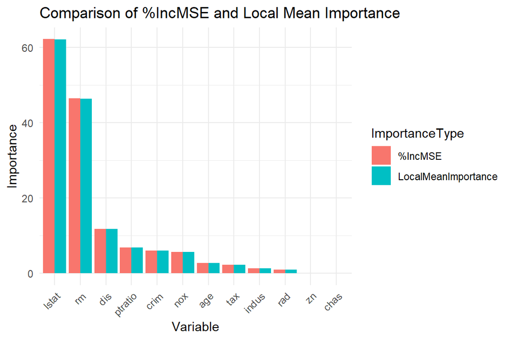

```r
df_long <- combined_importance %>%
  pivot_longer(cols = c("%IncMSE", "LocalMeanImportance"),
               names_to = "ImportanceType",
               values_to = "Importance")

ggplot(df_long, aes(x = reorder(Variable, -Importance), y = Importance, fill = ImportanceType)) +
  geom_bar(stat = "identity", position = "dodge") +
  labs(
    x = "Variable",
    y = "Importance",
    title = "Comparison of %IncMSE and Local Mean Importance"
  ) +
  theme_minimal() +
  theme(axis.text.x = element_text(angle = 45, hjust = 1))
```

##### Nodepurity

**Local Importance Distributions Across Predictors**

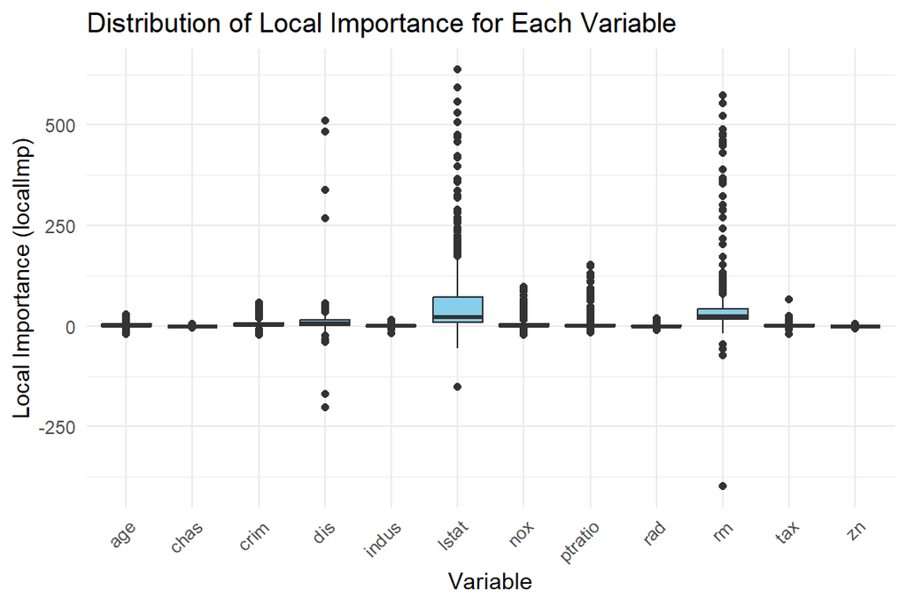

```r
library(ggplot2)
library(tidyr)

local_imp_df <- as.data.frame(localimp)
local_imp_df$Variable <- rownames(local_imp_df)
local_imp_long <- pivot_longer(local_imp_df,
                                cols = -Variable,
                                names_to = "Observation",
                                values_to = "Importance")

ggplot(local_imp_long, aes(x = Variable, y = Importance)) +
  geom_boxplot(fill = "skyblue") +
  labs(
    x = "Variable",
    y = "Local Importance (localImp)",
    title = "Distribution of Local Importance for Each Variable"
  ) +
  theme_minimal() +
  theme(axis.text.x = element_text(angle = 45, hjust = 1))
```

The boxplot of local importance (localImp) values provides further insights into how each predictor contributes to the random forest model’s predictions at the observation level. Variables such as **lstat** and **rm** exhibit substantial variability in their local importance, with a wide range of values and numerous extreme outliers. This indicates that these variables have a strong and heterogeneous impact on the model’s predictions across different observations. Specifically, **lstat** shows the highest dispersion, suggesting that it plays a particularly crucial role for certain subsets of the data. In contrast, variables like **chas**, **zn**, and **rad** display local importance values consistently close to zero, implying that they have minimal influence on predictions for most observations. These findings are consistent with the global variable importance measures, where **lstat** and **rm** also rank highest in terms of %IncMSE. Overall, the distribution of local importance highlights that while some variables have a uniformly weak effect, others exert substantial influence in a highly observation-specific manner, aligning with the heterogeneous nature of housing price determinants in the Boston dataset.

```r
bag.fit$importance
```

```
            %IncMSE IncNodePurity
crim     6.07226591    1503.62750
zn       0.06178714      36.77639
indus    1.33067903     241.78541
chas     0.03324793      31.50062
nox      5.69813516     988.64284
rm      46.43208489   16766.45020
age      2.68559319     559.26939
dis     11.74275957    2718.92071
rad      0.96777141     178.73888
tax      2.29943446     532.22062
ptratio  6.84170184     894.23484
lstat   62.23500602   16311.42126
```

```r
bag.fit$importanceSD
```

```
      crim         zn      indus       chas        nox         rm        age
0.38565891 0.02853056 0.12067264 0.04091198 0.23312356 0.76516020 0.17058721
       dis        rad        tax    ptratio      lstat
0.35849246 0.18755410 0.17395149 0.30417615 1.46998271
```

The variable bag.fit$importanceSD contains the standard deviations of the %IncMSE variable importance measure across all trees for each predictor in the random forest model. It quantifies the variability (or uncertainty) of the %IncMSE values across trees.

Relationship:

bag.fit$importance provides the mean %IncMSE across trees (i.e., the averaged increase in MSE when permuting a variable).

bag.fit$importanceSD provides the standard deviation of %IncMSE across trees, reflecting how consistent (or unstable) the importance of that variable is from tree to tree.

Calculation Process:

1. Out-of-Bag (OOB) Samples for Each Tree For each tree in the Random Forest, there are some observations not used to train that tree (the OOB samples).
2. Permutation on OOB Samples For each predictor (variable), permute (randomly shuffle) its values among the OOB samples. Measure the increase in the tree’s prediction error (MSE) after this permutation compared to the original OOB MSE.
3. Per-Tree %IncMSE For each variable and for each tree, calculate the percentage increase in OOB MSE caused by permuting that variable:

$$\%\text{IncMSE}_{j}^{(t)} = \frac{\text{MSE}_{\text{perm}(j)}^{(t)} - \text{MSE}_{\text{orig}}^{(t)}}{\text{MSE}_{\text{orig}}^{(t)}} \times 100$$

Where: - $t$: index for the tree - $j$: index for the variable - $\text{MSE}_{\text{orig}}$: OOB MSE without permutation - $\text{MSE}_{\text{perm}}$: OOB MSE after permutation of variable $j$

4. Aggregate Across Trees For each variable $j$, collect a set of $\%\text{IncMSE}_{j}^{(1)}, \%\text{IncMSE}_{j}^{(2)}, \ldots, \%\text{IncMSE}_{j}^{(T)}$, where $T$ is the total number of trees.
5. Compute Mean and Standard Deviation
- **Mean** across trees → stored in `bag.fit$importance`
- **Standard Deviation** across trees → stored in `bag.fit$importanceSD`

$$\text{SD}(\%\text{IncMSE}_j) = \sqrt{\frac{1}{T-1} \sum_{t=1}^T \left( \%\text{IncMSE}_j^{(t)} - \overline{\%\text{IncMSE}_j} \right)^2}$$

#### SD,localImp

```r
impsd <- bag.fit$importanceSD
local_sd <- apply(localimp, 1, sd, na.rm = TRUE)
# mean(localImp) as baseline MSE
local_mean <- apply(localimp, 1, function(x) mean(abs(x), na.rm = TRUE))
local_sd_percent <- local_sd / local_mean  # 转为“相对变异程度（%）”

local_sd_percent
```

```
    crim       zn    indus     chas      nox       rm      age      dis
1.321249 2.706820 1.511050 3.464575 1.996427 1.738036 1.222340 2.812946
     rad      tax  ptratio    lstat
2.007733 1.566993 2.914907 1.536481
```

```r
impsd
```

```
      crim         zn      indus       chas        nox         rm        age
0.38565891 0.02853056 0.12067264 0.04091198 0.23312356 0.76516020 0.17058721
       dis        rad        tax    ptratio      lstat
0.35849246 0.18755410 0.17395149 0.30417615 1.46998271
```

### Interpretation of `local_sd_percent`

The `local_sd_percent` metric measures the **relative variability** of a variable’s local importance across individual observations. It is calculated as:

$$\text{local_sd_percent}_j = \frac{\text{SD}(\text{localImp}_j)}{\text{Mean}(|\text{localImp}_j|)}$$

Where: - $\text{SD}(\text{localImp}_j)$ is the sample-wise standard deviation of variable $j$’s local importance values(for each row). - $\text{Mean}(|\text{localImp}_j|)$ is the average absolute importance of variable $j$ across all OOB samples.

This normalized ratio allows us to understand **how consistently** a variable influences different observations.  
- A **higher** `local_sd_percent` means the variable has **heterogeneous local effects**, impacting some observations strongly and others weakly. - A **lower** value suggests **uniform and stable importance** across samples.

It complements `importanceSD` (tree-wise standard deviation), offering insight into **local vs. global variability** of predictor effects.

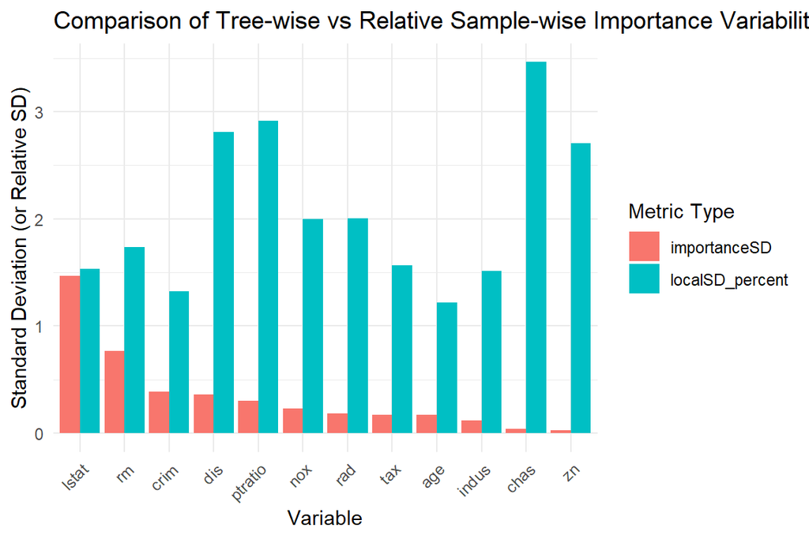

```r
sd_df <- data.frame(
  Variable = names(impsd),
  importanceSD = as.vector(impsd),
  localSD_percent = local_sd_percent[names(impsd)]
)

sd_df$Variable <- factor(sd_df$Variable,
                         levels = sd_df$Variable[order(sd_df$importanceSD, decreasing = TRUE)])

sd_long <- pivot_longer(sd_df,
                        cols = c("importanceSD", "localSD_percent"),
                        names_to = "Type",
                        values_to = "SD")

library(ggplot2)
ggplot(sd_long, aes(x = Variable, y = SD, fill = Type)) +
  geom_bar(stat = "identity", position = "dodge") +
  labs(
    title = "Comparison of Tree-wise vs Relative Sample-wise Importance Variability",
    x = "Variable",
    y = "Standard Deviation (or Relative SD)",
    fill = "Metric Type"
  ) +
  theme_minimal() +
  theme(axis.text.x = element_text(angle = 45, hjust = 1))
```

While global metrics like `importanceSD` are essential for understanding **overall feature robustness**, they can overlook **individual-level predictive dynamics**. The `localSD_percent` serves as a complementary diagnostic, uncovering variables that contribute significantly to error reduction **in heterogeneous or edge-case samples**.

### Variable Importacne(Regression)

Permutation Importance based on MSE Increase: Randomly shuffle the values of a specific variable (on the out-of-bag data) and compare the increase in model prediction error (MSE) to assess the importance of the variable.

In Breiman’s book, the importance of the variable is measured by the v alue of “percentage of increase of mean square error” (Increase in MSE(%)) in Random Forest, where a higher MSE% value means a more important variable.

The formula is as follows:

$$\%\text{IncMSE}_j = \frac{ \text{MSE}_{\text{perm}(j)} - \text{MSE}_{\text{orig}} }{ \text{MSE}_{\text{orig}} } \times 100$$

Where:

- $\text{MSE}_{\text{orig}}$: Original OOB MSE without permutation
- $\text{MSE}_{\text{perm}(j)}$: OOB MSE after permuting variable $j$

A higher %IncMSE means that permuting the variable causes a larger increase in error, indicating higher importance.

```r
# Load required libraries
library(randomForest)
library(ISLR2)  # for Boston dataset
library(vip)    # for variable importance plots
library(dplyr)
library(ggplot2)

# Set seed for reproducibility
set.seed(150)

# Prepare data
train <- sample(nrow(Boston), .98*nrow(Boston))
train_dat <- Boston[train,]
test_dat <- Boston[-train,]

# Fit the bagging model (Random Forest with mtry = p)
bag.fit <- randomForest(
  medv ~ ., data = train_dat,
  mtry = ncol(Boston) - 1,    # p = 12 predictors (bagging)
  ntree = 500,
  importance = TRUE,          # store variable importance
  keep.inbag = TRUE
)

print("Original Random Forest Model:")
```

```
[1] "Original Random Forest Model:"
```

```r
print(bag.fit)
```

```
Call:
 randomForest(formula = medv ~ ., data = train_dat, mtry = ncol(Boston) -      1, ntree = 500, importance = TRUE, keep.inbag = TRUE)
               Type of random forest: regression
                     Number of trees: 500
No. of variables tried at each split: 12

          Mean of squared residuals: 9.732018
                    % Var explained: 88.24
```

```r
# MANUAL CALCULATION OF VARIABLE IMPORTANCE (%IncMSE)
# Function to manually calculate %IncMSE for a given variable
calculate_manual_vi <- function(rf_model, train_data, variable_name) {

  # Step 1: Get original OOB predictions and calculate original MSE
  oob_pred_orig <- rf_model$predicted  # OOB predictions from original model
  y_true <- train_data$medv
  mse_orig <- mean((oob_pred_orig - y_true)^2)

  cat(sprintf("Original OOB MSE: %.4f\n", mse_orig))

  # Step 2: Create permuted dataset
  train_permuted <- train_data
  set.seed(123)  # for reproducibility of permutation
  train_permuted[[variable_name]] <- sample(train_permuted[[variable_name]])

  cat(sprintf("Permuting variable: %s\n", variable_name))

  # Step 3: Refit the model with permuted data
  rf_permuted <- randomForest(
    medv ~ ., data = train_permuted,
    mtry = ncol(Boston) - 1,
    ntree = 500,
    keep.inbag = TRUE
  )

  # Step 4: Get OOB predictions from permuted model and calculate new MSE
  oob_pred_perm <- rf_permuted$predicted
  mse_perm <- mean((oob_pred_perm - y_true)^2)

  cat(sprintf("Permuted OOB MSE: %.4f\n", mse_perm))

  # Step 5: Calculate %IncMSE
  percent_inc_mse <- (mse_perm - mse_orig) / mse_orig * 100

  cat(sprintf("Manual %%IncMSE for %s: %.4f\n", variable_name, percent_inc_mse))

  return(list(
    variable = variable_name,
    mse_orig = mse_orig,
    mse_perm = mse_perm,
    percent_inc_mse = percent_inc_mse
  ))
}

# CALCULATE FOR SPECIFIC VARIABLE (e.g., 'lstat')

cat("\n=== MANUAL CALCULATION FOR 'lstat' ===\n")
```

```
=== MANUAL CALCULATION FOR 'lstat' ===
```

```r
manual_vi_lstat <- calculate_manual_vi(bag.fit, train_dat, "lstat")
```

```
Original OOB MSE: 9.7320
Permuting variable: lstat
Permuted OOB MSE: 18.6953
Manual %IncMSE for lstat: 92.1011
```

```r
# COMPARE WITH BUILT-IN IMPORTANCE FUNCTION

cat("\n=== COMPARISON WITH BUILT-IN FUNCTIONS ===\n")
```

```
=== COMPARISON WITH BUILT-IN FUNCTIONS ===
```

```r
# Get built-in variable importance
vi_builtin <- importance(bag.fit, type = 1)  # type = 1 for %IncMSE
vi_lstat_builtin <- vi_builtin["lstat", "%IncMSE"]

cat(sprintf("Built-in %%IncMSE for lstat: %.4f\n", vi_lstat_builtin))
```

```
Built-in %IncMSE for lstat: 43.5057
```

```r
cat(sprintf("Manual %%IncMSE for lstat: %.4f\n", manual_vi_lstat$percent_inc_mse))
```

```
Manual %IncMSE for lstat: 92.1011
```

```r
cat(sprintf("Difference: %.4f\n", abs(vi_lstat_builtin - manual_vi_lstat$percent_inc_mse)))
```

```
Difference: 48.5954
```

```r
# CALCULATE FOR ALL VARIABLES (MANUAL vs BUILT-IN)

cat("\n=== CALCULATING FOR ALL VARIABLES ===\n")
```

```
=== CALCULATING FOR ALL VARIABLES ===
```

```r
# Get all variable names
all_vars <- names(train_dat)[names(train_dat) != "medv"]

# Manual calculation for all variables (this might take some time)
manual_vi_all <- data.frame(
  Variable = character(),
  Manual_IncMSE = numeric(),
  stringsAsFactors = FALSE
)

for (var in all_vars) {
  cat(sprintf("\nCalculating for %s...\n", var))
  manual_result <- calculate_manual_vi(bag.fit, train_dat, var)
  manual_vi_all <- rbind(manual_vi_all,
                        data.frame(Variable = var,
                                  Manual_IncMSE = manual_result$percent_inc_mse))
}
```

```
Calculating for crim...
Original OOB MSE: 9.7320
Permuting variable: crim
Permuted OOB MSE: 10.0833
Manual %IncMSE for crim: 3.6095

Calculating for zn...
Original OOB MSE: 9.7320
Permuting variable: zn
Permuted OOB MSE: 9.9177
Manual %IncMSE for zn: 1.9083

Calculating for indus...
Original OOB MSE: 9.7320
Permuting variable: indus
Permuted OOB MSE: 9.8373
Manual %IncMSE for indus: 1.0817

Calculating for chas...
Original OOB MSE: 9.7320
Permuting variable: chas
Permuted OOB MSE: 9.6166
Manual %IncMSE for chas: -1.1859

Calculating for nox...
Original OOB MSE: 9.7320
Permuting variable: nox
Permuted OOB MSE: 11.2771
Manual %IncMSE for nox: 15.8761

Calculating for rm...
Original OOB MSE: 9.7320
Permuting variable: rm
Permuted OOB MSE: 14.8422
Manual %IncMSE for rm: 52.5092

Calculating for age...
Original OOB MSE: 9.7320
Permuting variable: age
Permuted OOB MSE: 10.1403
```

[output cut: 16 more lines]

```
Permuting variable: tax
Permuted OOB MSE: 10.2434
Manual %IncMSE for tax: 5.2544

Calculating for ptratio...
Original OOB MSE: 9.7320
Permuting variable: ptratio
Permuted OOB MSE: 11.0092
Manual %IncMSE for ptratio: 13.1232

Calculating for lstat...
Original OOB MSE: 9.7320
Permuting variable: lstat
Permuted OOB MSE: 18.6953
Manual %IncMSE for lstat: 92.1011
```

```r
# Built-in importance for all variables
builtin_vi <- data.frame(
  Variable = rownames(vi_builtin),
  Builtin_IncMSE = vi_builtin[, "%IncMSE"]
)

# Combine results
comparison_df <- merge(manual_vi_all, builtin_vi, by = "Variable")
comparison_df$Difference <- abs(comparison_df$Manual_IncMSE - comparison_df$Builtin_IncMSE)
comparison_df <- comparison_df[order(-comparison_df$Builtin_IncMSE), ]

cat("\n=== COMPARISON TABLE ===\n")
```

```
=== COMPARISON TABLE ===
```

```r
print(comparison_df)
```

```
   Variable Manual_IncMSE Builtin_IncMSE  Difference
10       rm     52.509245     63.9509957 11.44175027
6     lstat     92.101084     43.5056945 48.59538950
4       dis     29.788203     31.9477811  2.15957806
7       nox     15.876092     25.9332621 10.05716981
8   ptratio     13.123181     23.7471730 10.62399156
3      crim      3.609508     16.8768352 13.26732697
11      tax      5.254363     16.6733496 11.41898699
1       age      4.194740     15.9165745 11.72183475
5     indus      1.081662     10.3091043  9.22744217
9       rad      5.567706      5.5153137  0.05239282
12       zn      1.908324      2.7516382  0.84331390
2      chas     -1.185924     -0.1290887  1.05683547
```

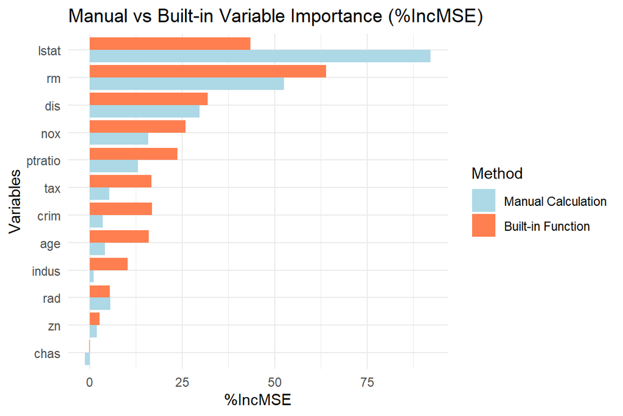

```r
# VISUALIZATION

# Create comparison plot
comparison_long <- reshape2::melt(comparison_df[, c("Variable", "Manual_IncMSE", "Builtin_IncMSE")],
                                 id.vars = "Variable")

p1 <- ggplot(comparison_long, aes(x = reorder(Variable, value), y = value, fill = variable)) +
  geom_bar(stat = "identity", position = "dodge") +
  coord_flip() +
  labs(title = "Manual vs Built-in Variable Importance (%IncMSE)",
       x = "Variables", y = "%IncMSE",
       fill = "Method") +
  scale_fill_manual(values = c("Manual_IncMSE" = "lightblue", "Builtin_IncMSE" = "coral"),
                    labels = c("Manual Calculation", "Built-in Function")) +
  theme_minimal()

print(p1)
```

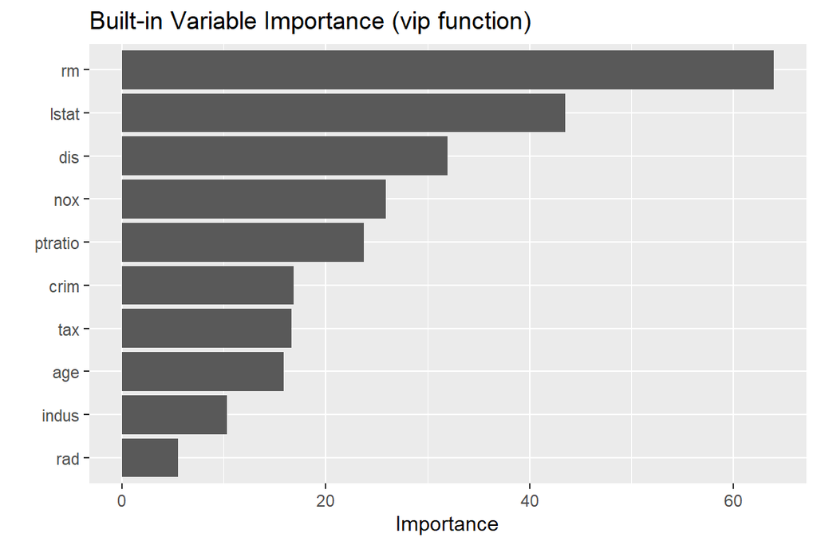

```r
# Plot using vip function for comparison
p2 <- vip(bag.fit, bar = TRUE) +
  ggtitle("Built-in Variable Importance (vip function)")

print(p2)
```

```r
# SUMMARY STATISTICS

cat("\n=== SUMMARY STATISTICS ===\n")
```

```
=== SUMMARY STATISTICS ===
```

```r
cat(sprintf("Mean absolute difference: %.6f\n", mean(comparison_df$Difference)))
```

```
Mean absolute difference: 10.872168
```

```r
cat(sprintf("Max absolute difference: %.6f\n", max(comparison_df$Difference)))
```

```
Max absolute difference: 48.595390
```

```r
cat(sprintf("Correlation between methods: %.6f\n",
            cor(comparison_df$Manual_IncMSE, comparison_df$Builtin_IncMSE)))
```

```
Correlation between methods: 0.805768
```

```r
# Show the most important variables from both methods
cat("\nTop 5 variables by built-in method:\n")
```

```
Top 5 variables by built-in method:
```

```r
print(head(comparison_df[, c("Variable", "Builtin_IncMSE")], 5))
```

```
   Variable Builtin_IncMSE
10       rm       63.95100
6     lstat       43.50569
4       dis       31.94778
7       nox       25.93326
8   ptratio       23.74717
```

```r
cat("\nTop 5 variables by manual method:\n")
```

```
Top 5 variables by manual method:
```

```r
print(head(comparison_df[order(-comparison_df$Manual_IncMSE), c("Variable", "Manual_IncMSE")], 5))
```

```
   Variable Manual_IncMSE
6     lstat      92.10108
10       rm      52.50925
4       dis      29.78820
7       nox      15.87609
8   ptratio      13.12318
```

```r
vi(bag.fit, bar = TRUE)
```

```
# A tibble: 12 × 2
   Variable Importance
   <chr>         <dbl>
 1 rm           64.0
 2 lstat        43.5
 3 dis          31.9
 4 nox          25.9
 5 ptratio      23.7
 6 crim         16.9
 7 tax          16.7
 8 age          15.9
 9 indus        10.3
10 rad           5.52
11 zn            2.75
12 chas         -0.129
```

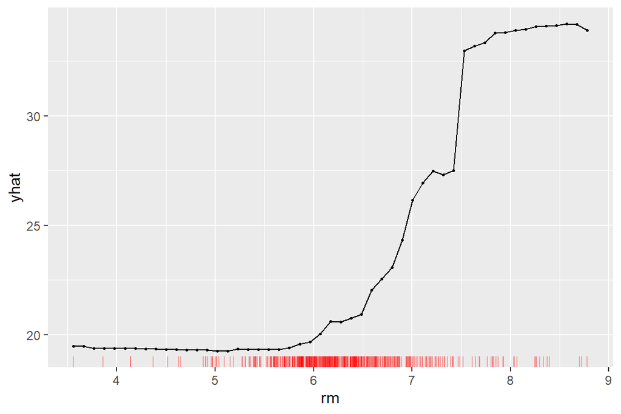

```r
# 4.  GLOBAL EFFECTS – PARTIAL DEPENDENCE
library(pdp)
## single feature
pdp.rm <- pdp::partial(bag.fit, pred.var = "rm", train = train_dat)
ggplot()+
  geom_line(data = pdp.rm, aes(x=rm,y=yhat))+
  geom_point(data = pdp.rm, aes(x=rm,y=yhat), size = .5)+
  geom_rug(data = train_dat,aes(rm),color = "red", alpha = .3)
```

This code creates a Partial Dependence Plot that shows how the predicted response (medv, median home value) changes as the value of rm changes, while holding all other variables constant (marginalizing them out).

`rm` is clearly positively associated with house value.The relationship is nonlinear and saturates beyond a point (around 7.5–8 rooms).

If the PDP varies a lot in a certain interval but the rug is very small, it means that the data in that interval is sparse and the PDP results may be unstable or unreliable.

The phenomenon observed in the figure: rm between 5 and 7 has the most data (rug density), and there are very few samples smaller than 4 or larger than 8.

Thus, the steep rise in PDP between 6.5 and 8 is plausible, while at the extremes (e.g., >8.5), PDP may be strongly influenced by small sample sizes.

```r
# ------------------------------------------------------------
# 1.  Build a PDP for every predictor in train_dat ------------
# ------------------------------------------------------------
vars <- setdiff(names(train_dat), "medv")     # all 12 predictors

pdp_list <- lapply(vars, function(v) {
  cat("→ computing PDP for", v, "\n")         # progress message
  pd <- pdp::partial(
    object            = bag.fit,
    pred.var          = v,
    train             = train_dat,
    grid.resolution   = 20,        # 20 grid points per variable
    progress          = "none"     # set to "text" if you like a progress bar
  )

  colnames(pd) <- c("value", "yhat")
  pd$Variable  <- v
  pd
})
```

```
→ computing PDP for crim
→ computing PDP for zn
→ computing PDP for indus
→ computing PDP for chas
→ computing PDP for nox
→ computing PDP for rm
→ computing PDP for age
→ computing PDP for dis
→ computing PDP for rad
→ computing PDP for tax
→ computing PDP for ptratio
→ computing PDP for lstat
```

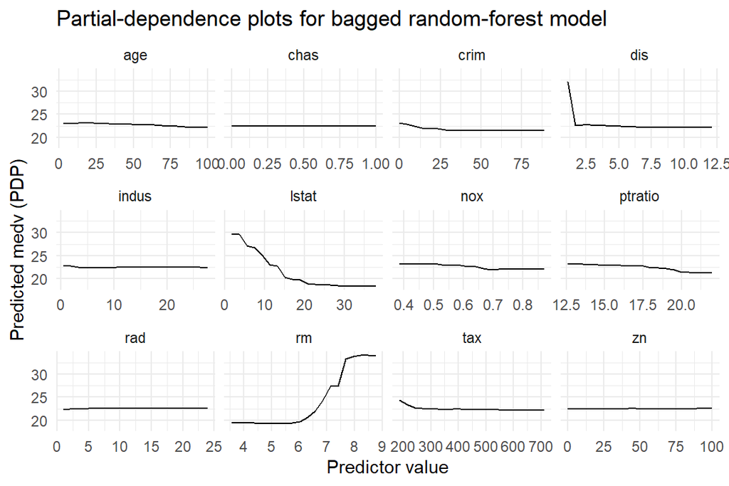

```r
plot_data <- bind_rows(pdp_list)

# ------------------------------------------------------------
# 2.  Faceted PDP plot ---------------------------------------
# ------------------------------------------------------------
ggplot(plot_data, aes(x = value, y = yhat)) +
  geom_line() +
  facet_wrap(~ Variable, scales = "free_x", ncol = 4) +
  labs(
    x     = "Predictor value",
    y     = "Predicted medv (PDP)",
    title = "Partial-dependence plots for bagged random-forest model"
  ) +
  theme_minimal()
```

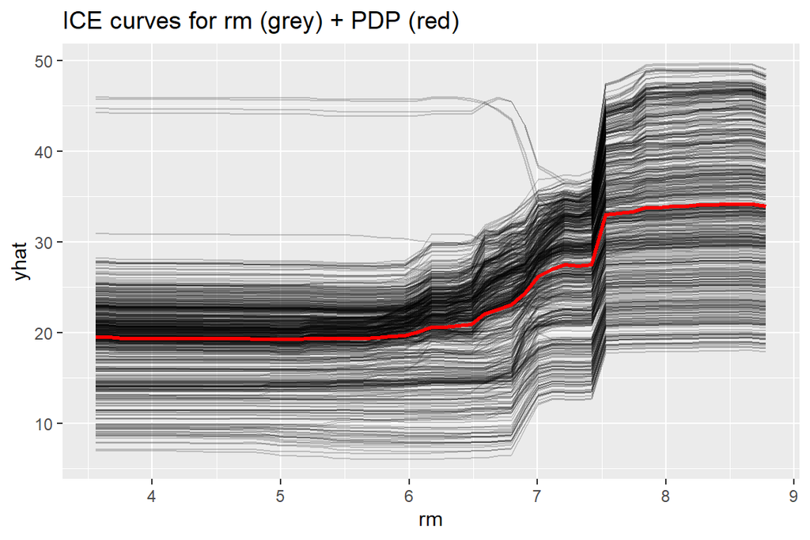

```r
library(pdp)       # partial(), ICE, PDP
library(dplyr)     # select, pipes
library(ggplot2)

# 1.  ICE curves for 'rm'
ice_rm <- partial(
  bag.fit,
  pred.var        = "rm",
  train           = train_dat,
  ice             = TRUE,
  progress        = "none"
)

autoplot(ice_rm, alpha = 0.2) +
  ggtitle("ICE curves for rm (grey) + PDP (red)")
```

Gray Curve ICE Curve (Individual Conditional Expectation):

- For each observation in the training set, fix the remaining 11 features and just let the rm slide over a series of grid points and record the predictions, and then connect those points to a line. Each gray line = a “local response curve” for a house.

Red Curve PDP (Partial Dependence):

- The predicted values of all ICE curves averaged over the same rm points are connected to a line, indicating the marginal effect of the overall average.

### Variable Importacne(Classification)

Gini Importance based on Node Impurity Reduction (applicable only to classification trees): Measures the total decrease in Gini impurity brought by a variable across all splits where it is used. The more a variable decreases impurity, the more important it is considered.

Let $p_{k}$ be the proportion of class $k$ observations in a node.  
The **Gini impurity** of a node is defined as:

$$G = 1 - \sum_{k=1}^{K} p_k^2$$

When a node is split on a variable, the decrease in impurity is calculated as:

$$\Delta G = G_{\text{parent}} - \left( \frac{n_{\text{left}}}{n_{\text{parent}}} G_{\text{left}} + \frac{n_{\text{right}}}{n_{\text{parent}}} G_{\text{right}} \right)$$

The total **Gini importance** for a variable is the sum of $\Delta G$ over all splits where this variable is used.

```r
library(ISLR2)
library(rpart)
library(tidyverse)
library(MASS)
# Fit a classification tree
kmod <- rpart(Kyphosis ~ Age + Number + Start,
              data = kyphosis,
              method = "class",
              control = rpart.control(cp = 0, minsplit = 2))

# View raw Gini importance from rpart
print(kmod$variable.importance)
```

```
      Age     Start    Number
14.770095 13.780608  3.208137
```

Manual Calculation of Gini Importance

```r
# Access the frame of the tree
frame <- kmod$frame
node_ids <- as.numeric(rownames(frame))

# Identify internal (split) nodes
split_nodes <- node_ids[frame$var != "<leaf>"]

# Initialize importance list
gini_importance <- list()

if(length(split_nodes) > 0) {
  for (node in split_nodes) {
    # Current node info
    parent_row <- which(rownames(frame) == as.character(node))
    parent_n <- frame$n[parent_row]
    parent_dev <- frame$dev[parent_row]
    varname <- frame$var[parent_row]

    cat("\nProcessing node", node, "- Variable:", varname, "\n")

    # Left and right child node IDs
    left_id <- as.character(2 * node)
    right_id <- as.character(2 * node + 1)

    # Check if both children exist
    if (left_id %in% rownames(frame) && right_id %in% rownames(frame)) {
      left_row <- which(rownames(frame) == left_id)
      right_row <- which(rownames(frame) == right_id)

      left_n <- frame$n[left_row]
      right_n <- frame$n[right_row]
      left_dev <- frame$dev[left_row]
      right_dev <- frame$dev[right_row]

      # Calculate weighted impurity decrease
      # Note: frame$dev in rpart contains deviance, not Gini impurity directly
      # For classification trees, deviance = 2 * n * Gini_impurity
      # So Gini_impurity = deviance / (2 * n)

      parent_gini <- parent_dev / (2 * parent_n)
      left_gini <- left_dev / (2 * left_n)
      right_gini <- right_dev / (2 * right_n)

      # Weighted average of child impurities
      weighted_child_gini <- (left_n * left_gini + right_n * right_gini) / parent_n

      # Decrease in Gini impurity
      delta_gini <- parent_gini - weighted_child_gini

      # For comparison with rpart's importance, we need to multiply by sample size
      # This gives the total impurity decrease weighted by the number of samples
      importance_contribution <- delta_gini * parent_n

      cat("  Delta Gini:", delta_gini, "Contribution:", importance_contribution, "\n")

      # Accumulate importance
      if (varname %in% names(gini_importance)) {
        gini_importance[[varname]] <- gini_importance[[varname]] + importance_contribution
      } else {
        gini_importance[[varname]] <- importance_contribution
      }
    }
  }
} else {
  cat("No internal nodes found - tree has no splits\n")
}
```

```
Processing node 1 - Variable: Start
  Delta Gini: 0.01851852 Contribution: 1.5

Processing node 2 - Variable: Start
  Delta Gini: 0 Contribution: 0

Processing node 5 - Variable: Age
  Delta Gini: 0 Contribution: 0

Processing node 11 - Variable: Age
  Delta Gini: 0.07142857 Contribution: 1.5

Processing node 22 - Variable: Start
  Delta Gini: 0 Contribution: 0

Processing node 44 - Variable: Age
  Delta Gini: 0 Contribution: 0

Processing node 89 - Variable: Age
  Delta Gini: 0.08333333 Contribution: 0.5

Processing node 45 - Variable: Age
  Delta Gini: 0.25 Contribution: 0.5

Processing node 23 - Variable: Start
  Delta Gini: 0.1 Contribution: 0.5

Processing node 3 - Variable: Age
  Delta Gini: 0.05263158 Contribution: 1

Processing node 7 - Variable: Start
  Delta Gini: 0 Contribution: 0

Processing node 14 - Variable: Age
  Delta Gini: 0.08333333 Contribution: 1

Processing node 29 - Variable: Age
  Delta Gini: 0.1 Contribution: 1

Processing node 58 - Variable: Number
  Delta Gini: 0.08333333 Contribution: 0.5

Processing node 117 - Variable: Age
  Delta Gini: 0 Contribution: 0

Processing node 234 - Variable: Age
  Delta Gini: 0.25 Contribution: 0.5
```

```r
# Convert to data frame and compare with rpart's output
if(length(gini_importance) > 0) {
  manual_importance <- unlist(gini_importance)

  # Create comparison table
  comparison_df <- data.frame(
    Variable = names(manual_importance),
    Manual_Gini_Importance = manual_importance,
    rpart_Gini_Importance = kmod$variable.importance[names(manual_importance)]
  )

  cat("\nComparison of Manual vs rpart Gini Importance:\n")
  print(comparison_df)
} else {
  cat("No importance calculated - no splits in tree\n")
}
```

```
Comparison of Manual vs rpart Gini Importance:
       Variable Manual_Gini_Importance rpart_Gini_Importance
Start     Start                    2.0             13.780608
Age         Age                    6.0             14.770095
Number   Number                    0.5              3.208137
```